# Improving stock price prediction accuracy using technical indicators and machine learning techniques

#### by Eugenio Cedric T. Corro

```python
import requests
import time
import json
import datetime
from tqdm import tqdm

import random
import pandas as pd
from pandas import read_csv
import numpy as np
import seaborn as sns
import matplotlib.pyplot as plt

from sklearn.model_selection import train_test_split
from sklearn.preprocessing import MinMaxScaler, StandardScaler

from sklearn.metrics import mean_squared_error, r2_score
from sklearn.metrics import auc, recall_score, precision_score
from sklearn.metrics import precision_recall_curve, confusion_matrix
from sklearn.metrics import plot_precision_recall_curve

from sklearn.ensemble import RandomForestRegressor, AdaBoostRegressor
from sklearn.ensemble import GradientBoostingRegressor, ExtraTreesRegressor
from sklearn.tree import DecisionTreeRegressor
from sklearn.neighbors import KNeighborsRegressor
from sklearn.svm import SVR
from sklearn.linear_model import LinearRegression
import xgboost as xgb

from sklearn.model_selection import RandomizedSearchCV, GridSearchCV
from statsmodels.tsa.arima_model import ARIMA
from math import sqrt

import warnings
warnings.filterwarnings("ignore")
pd.options.display.max_columns = None
# pd.options.display.max_rows = None

from IPython.core.display import HTML
import pprint

def mean_absolute_percentage_error(y_true, y_pred):
    """Return mean absolute percentage error of predicted values."""
    y_true, y_pred = np.array(y_true), np.array(y_pred)
    return np.mean(np.abs((y_true - y_pred) / y_true)) * 100
```

```python
font = "Roboto-Regular.ttf"
pp = pprint.PrettyPrinter(indent=4, width=100)


HTML('''
<style>
.output_png {
    display: table-cell;
    text-align: center;
    vertical-align: middle;
}

</style>


<script>
code_show=true;
function code_toggle() {
 if (code_show){
 $('div.input').hide();
 } else {
 $('div.input').show();
 }
 code_show = !code_show
}
$( document ).ready(code_toggle);
</script>
<form action="javascript:code_toggle()"><input type="submit" value="Click here to toggle on/off the raw code."></form>
''')
```

EXECUTIVE SUMMARY

Stock price prediction using various techniques is a classic problem that many researchers have been tackling for many years. Although efficient market hypothesis states that it is not possible to predict stock prices given its random nature, many still attempt to find patterns in price movements. Technical analysts take advantage of factors based on prices and volume to figure out potential opportunities to make money in the short- or long-run. In the Philippines, the Philippines Stock Exchange, Inc. (PSE) is the national stock exchange. In 2019, the PSE had a market capitalization of PhP 13.395 trillion with an average value turnover of PhP 7.29 billion.

1. **Among the three models used in this study, Auto Regressive Integrated Moving Average (ARIMA), Gradient Boosting Regression (GBR) with naive forecasting of features and a combination of ARIMA and GBR, ARIMA gave the smallest error measurements (MSE, RMSE, MAPE and last point MAPE).**
2. **The models considered were significantly improved by choosing a time interval as the train set which starts and ends at two different days, not necessarily consecutive, when the Relative Strength Index (RSI) touches the support level (RSI=30) from a declining trend.**

BUSINESS VALUE

**Stock traders and investors:** They can consider a different way of looking at moving average-based indicators as part of their decision when trading stocks.

**Researchers:** They can consider a rule-based selection of time intervals of stock prices when working with stock price prediction research.

DATA DESCRIPTION

```python
# def get_stocks(stock_code, start_date, end_date):
#     """
#     Get stock info from start_date to end_date.

#     PARAMETERS
#     ----------
#     stock_code : list
#         List of stock codes to retrieve info of.
#     start_date : str
#         Start date of data with format 'YYYY-MM-DD'.
#     end_date : str
#         End date of data with format 'YYYY-MM-DD'.

#     RETURN
#     ------
#     stocks : pandas.DataFrame
#         DataFrame with stock info name-price-symbol-date.
#     """

#     dates = (pd.date_range(start=start_date,
#                            end=end_date).to_series()
#                                         .apply(lambda x :
#                                                x.strftime("%Y-%m-%d")))

#     stocks = pd.DataFrame()
#     for code in stock_code:
#         for date in dates:
#             data = ''
#             wp_endpoint = ('http://phisix-api2.appspot.com/stocks/' + code
#                            + '.' + date +'.json')
#             data = requests.get(wp_endpoint).text
#             if data:
#                 stock = json.loads(data)
#                 stock_data = (pd.DataFrame(stock['stock'][0])
#                                           .reset_index(drop=True)
#                                           .drop(1)
#                                           .drop('percent_change', axis=1))
#                 stock_data['date'] = date
#                 stocks = stocks.append(stock_data)
#                 # time.sleep(0.5)
#     return stocks
```

```python
# stock_code = ['JFC']
# start_date = '2012-01-01'
# end_date = '2019-12-31'

# stocks = get_stocks(stock_code, start_date, end_date)
# stocks.to_csv('jfc_stocks_data.csv', index=False)
```

```python
df1 = pd.read_csv('jfc_stock_data.csv')
df = df1.copy()
```

```python
def get_returns(df):
    """Returns the daily returns of stock price."""
    df = df.reset_index(drop=True)
    day1 = np.array([0])
    rets = (df.price.diff()[1:].to_numpy() / df.price[:-1].to_numpy())
    df['returns'] = np.concatenate((day1, rets))
    return df[1:]


def compute_sma(stock):
    """Return SMAs."""
    for d in [5, 8, 13, 21, 50, 100]:
        stock['sma_' + str(d)] = stock.price.rolling(window=d).mean()
    return stock


def compute_ema(stock):
    """Return EMAs"""
    for d in [3, 9, 12, 16, 26, 200]:
        stock['ema_' + str(d)] = (stock.price
                                       .ewm(span=d, adjust=False)
                                       .mean())
    return stock


def compute_macd(stock):
    """Return MACD and MACD signal."""
    stock['macd'] = stock.ema_12 - stock.ema_26
    stock['macd_signal'] = stock.macd.ewm(span=9, adjust=False).mean()
    return stock


def compute_rsi(stock, period=14):
    """Return RSI."""
    close = stock.price
    delta = close.diff()
    gain, loss = delta.copy(), delta.copy()

    gain[gain < 0] = 0
    loss[loss > 0] = 0

    # Calculate the exponential moving averages (EWMA)
    roll_up = gain.ewm(com=period - 1, adjust=False).mean()
    roll_down = loss.ewm(com=period - 1, adjust=False).mean().abs()

    # Calculate RSI based on exponential moving average (EWMA)
    # relative strength =  average gain/average loss
    rs = roll_up / roll_down

    rsi = 100 - (100 / (1 + rs))
    stock['rsi'] = rsi
    return stock


def volume_minmax(stock):
    """Return MinMax scaled volume."""
    scaler = MinMaxScaler()
    stock['volume'] = scaler.fit_transform(stock[['volume']])
    return stock


def compute_derived_features(stock):
    """Return DataFrame with all derived features."""
    stock = compute_sma(stock)
    stock = compute_ema(stock)
    stock = compute_macd(stock)
    stock = compute_rsi(stock)
    stock = volume_minmax(stock)
    return stock


def diff_mas(stock):
    """Return MA differences."""
    smas = ['sma_5', 'sma_8', 'sma_13', 'sma_21', 'sma_50', 'sma_100']
    emas = ['ema_3', 'ema_9', 'ema_12', 'ema_16', 'ema_26', 'ema_200']

    for i in range(1, len(smas)):
        for j in range(i):
            stock[smas[i] + '_' + smas[j]] = ((stock[smas[i]] -
                                               stock[smas[j]]) /
                                               stock['price'])
            stock[emas[i] + '_' + emas[j]] = ((stock[emas[i]] -
                                              stock[emas[j]]) /
                                              stock['price'])
    return stock
```

The following data are included in this study.

| Data Field | Description |
| --- | --- |
| price | Daily closing price (PhP) |
| volume | Number of shares traded daily |
| date | Date of trading |
| returns | Daily percentage change |
| sma_n | n-day simple moving average (SMA-n) of prices |
| ema_m | m-day exponential moving average (EMA-m) of prices |
| sma_n_sma_m | Difference of SMA-n and SMA-m |
| ema_n_ema_m | Difference of EMA-n and EMA-m |
| macd | Moving average convergence-divergence; difference between EMA-12 and EMA-26 |
| macd_signal | EMA-9 of MACD |
| rsi | Relative Strength Index |

```python
# Calculate daily returns of stock price
jfc = get_returns(df[df.symbol == 'JFC'])

# Calculate derived features
jfc = compute_derived_features(jfc)
jfc = jfc[100:].reset_index(drop=True)

# Calculate differences of smas and emas
smas = ['sma_5', 'sma_8', 'sma_13', 'sma_21', 'sma_50', 'sma_100']
emas = ['ema_3', 'ema_9', 'ema_12', 'ema_16', 'ema_26', 'ema_200']
jfc = diff_mas(jfc)
jfc = jfc.drop(smas + emas, axis=1)
jfc.head()
```

|  | name | price | volume | symbol | date | returns | macd | macd_signal | rsi | sma_8_sma_5 | ema_9_ema_3 | sma_13_sma_5 | ema_12_ema_3 | sma_13_sma_8 | ema_12_ema_9 | sma_21_sma_5 | ema_16_ema_3 | sma_21_sma_8 | ema_16_ema_9 | sma_21_sma_13 | ema_16_ema_12 | sma_50_sma_5 | ema_26_ema_3 | sma_50_sma_8 | ema_26_ema_9 | sma_50_sma_13 | ema_26_ema_12 | sma_50_sma_21 | ema_26_ema_16 | … |
| --- | --- | --- | --- | --- | --- | --- | --- | --- | --- | --- | --- | --- | --- | --- | --- | --- | --- | --- | --- | --- | --- | --- | --- | --- | --- | --- | --- | --- | --- | --- |
| 0 | Jollibee | 252.8 | 0.015847 | JFC | 2016-08-18 | 0.006369 | 1.548682 | 2.462035 | 52.571503 | 0.002176 | 0.002490 | 0.005842 | 0.002823 | 0.003667 | 0.000332 | 0.005764 | 0.002070 | 0.003588 | -0.000420 | -0.000078 | -0.000752 | -0.026361 | -0.003303 | -0.028536 | -0.005794 | -0.032203 | -0.006126 | -0.032125 | -0.005374 | … |
| 1 | Jollibee | 252.6 | 0.020599 | JFC | 2016-08-19 | -0.000791 | 1.387488 | 2.247126 | 52.174463 | 0.000317 | 0.001838 | 0.005737 | 0.002211 | 0.005421 | 0.000373 | 0.006161 | 0.001630 | 0.005844 | -0.000208 | 0.000423 | -0.000581 | -0.024513 | -0.003282 | -0.024830 | -0.005120 | -0.030250 | -0.005493 | -0.030674 | -0.004912 | … |
| 2 | Jollibee | 253.0 | 0.018867 | JFC | 2016-08-22 | 0.001584 | 1.277293 | 2.053159 | 52.939973 | 0.000711 | 0.000916 | 0.005485 | 0.001231 | 0.004773 | 0.000315 | 0.005775 | 0.000732 | 0.005063 | -0.000184 | 0.000290 | -0.000498 | -0.022656 | -0.003818 | -0.023368 | -0.004734 | -0.028141 | -0.005049 | -0.028431 | -0.004550 | … |
| 3 | Jollibee | 253.0 | 0.052384 | JFC | 2016-08-23 | 0.000000 | 1.176402 | 1.877808 | 52.939973 | 0.000711 | 0.000457 | 0.003357 | 0.000723 | 0.002645 | 0.000266 | 0.005812 | 0.000295 | 0.005101 | -0.000163 | 0.002456 | -0.000429 | -0.020917 | -0.003927 | -0.021628 | -0.004384 | -0.024274 | -0.004650 | -0.026729 | -0.004221 | … |
| 4 | Jollibee | 250.0 | 0.037176 | JFC | 2016-08-24 | -0.011858 | 0.844633 | 1.671173 | 46.470105 | 0.000180 | 0.003830 | 0.002818 | 0.004612 | 0.002638 | 0.000782 | 0.006804 | 0.004673 | 0.006624 | 0.000843 | 0.003985 | 0.000061 | -0.018688 | 0.001233 | -0.018868 | -0.002597 | -0.021506 | -0.003379 | -0.025492 | -0.003440 | … |

METHODOLOGY

### 1. Dimensionality Reduction (PCA)

Before using the data to develop the model, the dimension (number of columns) of the data set was reduced using Principal Component Analysis (PCA). Retaining 99% of the variance explained, the top two principal components were used in the development of the model.

```python
def pca(X):
    """Return rotated design matrix, new coordinate system and variance
    explained.
    """
    # Mean-center data set.
    X_mc = X - np.outer(np.ones(X.shape[0]), X.mean(0))
    eigval, eigvec = np.linalg.eig((X_mc.T).dot(X_mc))
    eigval_srtd = eigval[np.argsort(eigval)[::-1]] / eigval.sum()
    eigvec_srtd = eigvec[:, np.argsort(eigval)[::-1]]

    # Plot variance explained.
    variance_explained = eigval_srtd
    plt.plot(range(1, len(variance_explained)+1), variance_explained, 'o-')
    plt.ylim(0,1)
    plt.xlabel('PC')
    plt.ylabel('variance explained')
    plt.show();

    return X_mc.dot(eigvec_srtd), eigvec_srtd, variance_explained


def project_pca(stock, X_new, n_components=2):
    """Return DataFrame with the selected first few components."""
    X_new = np.real(X_new)

    # Get first n components
    X_new1 = pd.DataFrame(X_new).iloc[:,:n_components]
    X_new1.columns = ["PC" + str(x + 1) for x in range(n_components)]

    # Replace with PCA
    stock_new = stock.iloc[:,:6].merge(X_new1, left_index=True,
                                       right_index=True)

    return stock_new
```

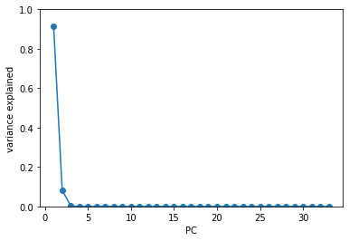

|  | name | price | volume | symbol | date | returns | PC1 | PC2 |
| --- | --- | --- | --- | --- | --- | --- | --- | --- |
| 0 | Jollibee | 252.8 | 0.015847 | JFC | 2016-08-18 | 0.006369 | -3.709140 | -2.090606 |
| 1 | Jollibee | 252.6 | 0.020599 | JFC | 2016-08-19 | -0.000791 | -3.241333 | -1.996930 |
| 2 | Jollibee | 253.0 | 0.018867 | JFC | 2016-08-22 | 0.001584 | -3.861070 | -1.496300 |
| 3 | Jollibee | 253.0 | 0.052384 | JFC | 2016-08-23 | 0.000000 | -3.786063 | -1.311241 |
| 4 | Jollibee | 250.0 | 0.037176 | JFC | 2016-08-24 | -0.011858 | 2.303644 | -3.483241 |

```python
stock = jfc.copy()
X_new, w, variance_explained = pca(stock.drop(['name', 'symbol', 'returns',
                                              'volume', 'price', 'date'],
                                              axis=1))
stock_new = project_pca(stock, X_new, n_components=2)
stock_new.head()
```

### 2. Model development

In this study, three models are considered in predicting the future stock price of JFC. A brief description is shown as follows.

1. **Gradient boosting regression and naive forecasting.** Since the features are data that are not available prior to the closing price to be predicted, naive method of forecasting was applied on the features to determine their values in the next $n$ days, that is, the feature values of the last $n$ days were used to set the feature values of the next $n$ days. Using the predicted feature values, gradient boosting regression is used to predicted the stock price of JFC.

[figure not shown]

1. **ARIMA on stock prices.** In this case, only the daily closing prices were used tp predict the stock price of JFC in the next $n$ days.

[figure not shown]

1. **ARIMA on the features and gradient boosting regression on the stock price.** This case is similar to (1) except that we use ARIMA in predicting the feature values instead of the naive method of forecasting. Then, we use gradient boossting regression on the predicted feature values to predicted the stock price of JFC.

[figure not shown]

### 3. Train-test Interval selection

In selecting the time interval of the stock prices to be used in the training and testing of the model, two setups were considered to predict the closing price of JFC in the *next 10 days*.

1. **Partitioned Intervals**: In this setup, 15 intervals were considered with train size of 100. The starting days between intervals are spaced by 50 trading days.
2. **RSI-based Intervals**: In this setup, a train set/interval starts and ends at two different days when the RSI touches the support level (RSI=30) from a declining trend. These points of *"RSI support kiss"* need not be consecutive.

### 4. Model Accuracy Measurement

In determining which model and setup gave the best results, the following error metrics were used.

1. **Mean Squared Error (MSE)**
2. **Root Mean Squared error (RMSE)**
3. **Mean Absolute Percentage Error (MAPE)**
4. **Last Point MAPE**: MAPE of the nth (last) predicted price

Note that the goal here is to **minimize these errors**.

RESULTS AND DISCUSSIONS

```python
def regressor_model(stock, model_name, mod, num_preds, train_size):
    """Return performance of model using Naive method for predicting
    features.
    """
    stock = stock.drop(['name', 'symbol', 'date', 'returns', 'volume'],axis=1)

    y_train = stock.price[ : train_size].to_numpy()
    X_train = stock.drop('price', axis=1)[ : train_size].to_numpy()

    y_test = stock.price[train_size : (train_size + num_preds)].to_numpy()
    #Naive assumption
    X_test = X_train[-num_preds:]

    mod.fit(X_train, y_train)
    y_pred = mod.predict(X_test)
    y_pred_train = mod.predict(X_train)

    plt.figure(figsize=(10,5))
    plt.plot(range(len(y_pred)), y_pred, 'o-', color='red', label='Prediction')
    plt.plot(range(len(y_test)), y_test, 'o-', color='blue', label='Actual')
    plt.legend()
    plt.show()

    mse = mean_squared_error(y_test, y_pred)
    rmse = sqrt(mean_squared_error(y_test, y_pred))
    mape = mean_absolute_percentage_error(y_test, y_pred)
    lastpoint_mape = mean_absolute_percentage_error(y_test[-1], y_pred[-1])

    train_mse = mean_squared_error(y_train, y_pred_train)
    train_rmse = sqrt(train_mse)
    train_mape = mean_absolute_percentage_error(y_train, y_pred_train)

    return pd.DataFrame({'Regression Method' : [model_name],
                         'Train MSE' : [train_mse],
                         'Train RMSE' : [train_rmse],
                         'Train MAPE' : [train_mape],
                         'Test MSE' : [mse],
                         'Test RMSE' : [rmse],
                         'Test MAPE' : [mape],
                         'Last point MAPE' : [lastpoint_mape]
                        })


# ARIMA
def difference(dataset, interval=1):
    """Return differenced series."""
    diff = list()
    for i in range(interval, len(dataset)):
        value = dataset[i] - dataset[i - interval]
        diff.append(value)
    return np.array(diff)


def inverse_difference(history, yhat, interval=1):
    """Return invert-differenced value."""
    return yhat + history[-interval]


def evaluate_arima_model(X, arima_order, num_preds, train_size):
    """Return RMSE of ARIMA model given order (p, d, q)."""

    X = X.astype('float32')
    train= X[ : train_size]
    test = X[train_size : (train_size + num_preds)]
    history = [x for x in train]
    predictions = list()

    for t in range(len(test)):
        # Difference data
        interval_diff = 1
        diff = difference(history, interval_diff)
        model = ARIMA(diff, order=arima_order)
        model_fit = model.fit(trend='nc', disp=0)
        yhat = model_fit.forecast()[0]
        yhat = inverse_difference(history, yhat, interval_diff)
        predictions.append(yhat)
        history.append(test[t])

    # Calculate error metrics
    mse = mean_squared_error(test, predictions)
    rmse = sqrt(mse)

    return rmse


def evaluate_models(dataset, p_val, d_val, q_val, num_preds, train_size):
    """Return order (p,d,q) with the best ARIMA results."""

    dataset = dataset.astype('float32')
    best_score, best_cfg = float("inf"), None
    for p in tqdm(p_val):
        for d in d_val:
            for q in q_val:
                order = (p,d,q)
                try:
                    mse = evaluate_arima_model(dataset, order, num_preds,
                                               train_size)
                    if mse < best_score:
                        best_score, best_cfg = mse, order
                except:
                    continue
    # print('Best ARIMA%s RMSE=%.3f' % (best_cfg, best_score))
    return best_cfg


def evaluate_best(dataset, p_val, d_val, q_val, num_preds, train_size):
    """Return error metric results of the best order (p,d,q) for ARIMA."""

    arima_order = evaluate_models(dataset,
                                  p_val, d_val, q_val,
                                  num_preds, train_size)
    X = dataset
    X = X.astype('float32')
    train= X[ : train_size]
    test = X[train_size : (train_size + num_preds)]
    history = [x for x in train]
    predictions = list()

    for t in range(len(test)):
        # Difference data
        interval_diff = 1
        diff = difference(history, interval_diff)
        model = ARIMA(diff, order=arima_order)
        model_fit = model.fit(trend='nc', disp=0)
        yhat = model_fit.forecast()[0]
        yhat = inverse_difference(history, yhat, interval_diff)
        predictions.append(yhat)
        history.append(test[t])

    # Calculate error
    mse = mean_squared_error(test, predictions)
    rmse = sqrt(mse)
    mape = mean_absolute_percentage_error(test, predictions)
    lastpoint_mape = mean_absolute_percentage_error(test[-1], predictions[-1])

    plt.figure(figsize=(10,5))
    plt.plot(range(len(predictions)), predictions, 'o-', color='red',
             label='Prediction')
    plt.plot(range(len(test)), test, 'o-', color='blue', label='Actual')
    plt.legend()
    plt.show()

    return pd.DataFrame({'Regression Method' : ['ARIMA'],
                         'Test MSE' : [mse],
                         'Test RMSE' : [rmse],
                         'Test MAPE' : [mape],
                         'Last point MAPE' : [lastpoint_mape]
                        })


def get_best_prediction(dataset, p_val, d_val, q_val, num_preds, train_size):
    """Return predicted prices using ARIMA with best results."""

    arima_order = evaluate_models(dataset, p_val, d_val, q_val,
                                  num_preds, train_size)
    X = dataset
    X = X.astype('float32')
    train= X[ : train_size]
    test = X[train_size : (train_size + num_preds)]
    history = [x for x in train]
    predictions = list()

    for t in range(len(test)):
        # Difference data
        diff = difference(history, 1)
        model = ARIMA(diff, order=arima_order)
        model_fit = model.fit(trend='nc', disp=0)
        yhat = model_fit.forecast()[0]
        yhat = inverse_difference(history, yhat, 1)
        predictions.append(yhat)
        history.append(test[t])

    # Calculate sample error
    mse = mean_squared_error(test, predictions)
    rmse = sqrt(mse)
    mape = mean_absolute_percentage_error(test, predictions)

    return predictions


def regressor_model_plus(stock, model_name, mod, num_preds, train_size,
                         p_values, d_values, q_values):
    """Return error metric results of ARIMA + regressor combination."""

    stock = stock.drop(['name', 'symbol', 'date'], axis=1)
    features = stock.drop('price', axis=1).columns
    feature_cols = stock.drop('price', axis=1)

    y_train = stock.price[ : train_size]
    X_train = stock.drop('price', axis=1)[ : train_size]
    y_test = stock.price[train_size : (train_size + num_preds)].to_numpy()

    # Perform ARIMA on each feature
    X_test = pd.DataFrame()
    for col in tqdm(features):
        X_test[col] = get_best_prediction(feature_cols[col].values,
                                          p_values, d_values, q_values,
                                          num_preds, train_size)
    mod.fit(X_train, y_train)
    y_pred = mod.predict(X_test)

    plt.figure(figsize=(10,5))
    plt.plot(range(len(y_pred)), y_pred, 'o-', color='red', label='Prediction')
    plt.plot(range(len(y_test)), y_test, 'o-', color='blue', label='Actual')
    plt.legend()
    plt.show()

    mse = mean_squared_error(y_test, y_pred)
    rmse = sqrt(mean_squared_error(y_test, y_pred))
    mape = mean_absolute_percentage_error(y_test, y_pred)
    lastpoint_mape = mean_absolute_percentage_error(y_test[-1], y_pred[-1])

    return pd.DataFrame({'Regression Method' : [model_name],
                         'Test MSE' : [mse],
                         'Test RMSE' : [rmse],
                         'Test MAPE' : [mape],
                         'Last point MAPE' : [lastpoint_mape]
                        })


def plot_stock(X):
    """Display price-macd-rsi graph of a stock."""
    fig, ax = plt.subplots(2, 1, figsize=(18, 12), sharex=True,
                           constrained_layout=True,
                           gridspec_kw={'height_ratios': [3, 1]})
    # PRICE
    ax[0].plot(range(len(X.price)), X.price)
    ax[0].set_title("JFC Stock Price (Jan 2012 to Dec 2019)", fontsize=18)
    ax[0].set_ylabel('Price', fontsize=15)
    ax[0].grid(True)

#     # MACD Signal
#     ax[1].plot(range(len(X.macd_signal)), X.macd_signal)
#     ax[1].set_title("MACD Signal", fontsize=18)
#     ax[1].grid(True)
#     ax[1].hlines(y=[0], xmin=-10, xmax=len(X), linestyles='dashed')

    # RSI
    ax[1].plot(range(len(X.rsi)), X.rsi)
    ax[1].set_title("RSI", fontsize=18)
    ax[1].set_xlabel('Day', fontsize=15)
    ax[1].set_xticks(range(0, len(X), 10))
    for tick in ax[1].get_xticklabels():
        tick.set_rotation(90)
    ax[1].grid(True)
    ax[1].hlines(y=[30, 80], xmin=-10, xmax=len(X), linestyles='dashed')

    ax
    return None
```

```python
def run_partitioned_intervals(X):
    """Return accuracy (error metrics) of model based on equally partitioned
    data set.
    """
    mod1 = GradientBoostingRegressor(n_estimators=100,max_depth=10)

    num_preds = 10
    train_size = 100
    p_values = range(0, 2)
    d_values = range(0, 2)
    q_values = range(0, 2)

    iters = 0
    for start in tqdm(range(0, 750, 50)):
        iters += 1
        perf1 = regressor_model(X[start:], 'GBR', mod1, num_preds, train_size)
        perf2 = evaluate_best(X.price[start:].to_numpy(), p_values, d_values,
                              q_values, num_preds, train_size)
        perf3 = regressor_model_plus(X[start:], 'ARIMA + GBR', mod1,
                                     num_preds, train_size, p_values,
                                     d_values, q_values)

    perf = pd.DataFrame(columns=['Model', 'No. of Intervals', 'Ave. MSE',
                                 'Ave. RMSE', 'Ave. MAPE',
                                 'Ave. Last Point MAPE'])
    perf.loc[0] = ['GBR', iters] + perf1.mean()[-4:].tolist()
    perf.loc[1] = ['ARIMA', iters] + perf2.mean()[-4:].tolist()
    perf.loc[2] = ['ARIMA + GBR', iters] + perf3.mean()[-4:].tolist()

    return perf


def run_rsi_based_intervals(X):
    """Return accuracy (error metrics) of model with train sets based on RSI
    values.
    """
    mod1 = GradientBoostingRegressor(n_estimators=100,max_depth=10)
    rsi_bottoms = [60, 85, 145, 450, 517, 645]

    num_preds = 10
    p_values = range(0, 2)
    d_values = range(0, 2)
    q_values = range(0, 2)

    iters = 0
    for i in tqdm(range(1, len(rsi_bottoms))):
        for j in range(i):
            iters += 1
            train_size = rsi_bottoms[i] - rsi_bottoms[j]
            start = rsi_bottoms[j]
            perf1 = regressor_model(X[start:], 'GBR', mod1, num_preds,
                                    train_size)
            perf2 = evaluate_best(X.price[start:].to_numpy(), p_values,
                                  d_values, q_values, num_preds, train_size)
            perf3 = regressor_model_plus(X[start:], 'ARIMA + GBR', mod1,
                                         num_preds, train_size, p_values,
                                         d_values, q_values)

    perf = pd.DataFrame(columns=['Model', 'No. of Intervals', 'Ave. MSE',
                                 'Ave. RMSE', 'Ave. MAPE',
                                 'Ave. Last Point MAPE'])
    perf.loc[0] = ['GBR', iters] + perf1.mean()[-4:].tolist()
    perf.loc[1] = ['ARIMA', iters] + perf2.mean()[-4:].tolist()
    perf.loc[2] = ['ARIMA + GBR', iters] + perf3.mean()[-4:].tolist()

    return perf
```

[figure not shown]

```python
plot_stock(jfc)
```

Observe that the *"RSI support kiss"* points happened on days 60, 85, 145, 450, 517 and 645. With these points, we can form 15 intervals (days 60 to 85, days 60 to 145, etc). Although there are other such points beyond day 645, we only considered these points to minimize the run-time of the Python program.

```python
# Load data to X
X = stock_new.copy()
```

### 1. Partitioned Intervals

Looking at the results of the partitioned intervals setup, it turns out that ARIMA gave the best results across all error metrics. On the other hand, one of the possible reasons that *ARIMA + GBR* gave a bad result is the possibility of the error being multiplied when the two models were implemented sequentially. Another possible reason is that the parameters used in implementing GBR might not be applicable to some of the intervals, and hence increasing the mean error.

```python
partition_perf = run_partitioned_intervals(X)
```

```python
partition_perf
```

|  | Model | No. of Intervals | Ave. MSE | Ave. RMSE | Ave. MAPE | Ave. Last Point MAPE |
| --- | --- | --- | --- | --- | --- | --- |
| 0 | GBR | 15 | 465.752053 | 21.581289 | 9.062032 | 11.999586 |
| 1 | ARIMA | 15 | 24.977457 | 4.997745 | 2.059519 | 0.417978 |
| 2 | ARIMA + GBR | 15 | 1335.583692 | 36.545638 | 14.467046 | 26.915071 |

### 2. RSI-based Intervals

In this setup of selecting intervals based on *"RSI support kiss"* points, the model accuracy improved significantly across all error metrics. Particularly, there is a great improvement on the models that performed badly in the partitioned intervals setup.

```python
rsi_perf = run_rsi_based_intervals(X)
```

```python
rsi_perf
```

|  | Model | No. of Intervals | Ave. MSE | Ave. RMSE | Ave. MAPE | Ave. Last Point MAPE |
| --- | --- | --- | --- | --- | --- | --- |
| 0 | GBR | 15 | 194.856568 | 13.959103 | 4.146493 | 0.662340 |
| 1 | ARIMA | 15 | 2.985962 | 1.727994 | 0.442762 | 0.331623 |
| 2 | ARIMA + GBR | 15 | 402.402996 | 20.059985 | 3.953681 | 2.023654 |

SUMMARY AND RECOMMENDATION

### Summary

1. Based on the models used in this study - (1) gradient boosting regression and naive forecasting, (2) ARIMA, and (3) gradient boosting regression and ARIMA - ARIMA gave the best results in terms of predicting stock prices.
2. By introducing a way of selecting an interval to consider in training a model based on RSI, the accuracy of the models in predicting the price of a stock was improved significantly.

### Recommendation:

1. To further validate the results in this study, the model can be used in other stocks.
2. Considering the idea that it takes time for a stock to reach an RSI of 30, other RSI levels can be tested in the method done in this study.
3. Observing how the selection of interval significantly improved the performance of the model, other technical indicators can be explored and incorporated in the selection of the interval where the model will be trained.

REFERENCES

[1] Patel, J., Shah, S., Thakkar and P., Kotecha, K. (2015). Predicting stock market index using fusion of machine learning techniques. *Expert Systems with Applications*, 42, 2162–2172

[2] Cam, J. (2015). The Trading Code. Laguna: Lex Media Digital Corp.

[3] Hyndman, R.J. and Athanasopoulos, G. (2018). Forecasting: principles and practice, 2nd edition, OTexts: Melbourne, Australia. OTexts.com/fpp2. Accessed on August 25, 2020.

[4] Gonzales, I. (2020). Market on short-lived high, but investors optimistic for 2020. Philstar Global. Retrieved from: https://www.philstar.com/business/2020/01/01/1981088/market-short-lived-high-investors-optimistic-2020

```python
! jupyter nbconvert --to html Corro_MLIndivProject.ipynb
```

```
[NbConvertApp] Converting notebook Corro_MLIndivProject.ipynb to html
[NbConvertApp] Writing 607135 bytes to Corro_MLIndivProject.html
```